# Food consumption and cancer

## 4.3 Cancer and food variables relations

In this section, we will explore in more depth the relationship with `got_cancer` and the variables related to our research questions. To study them, we will observe the proportion of cancer with these variables then we will model `got_cancer`, illustrate the relationship between each variable individually with got_cancer and finally interpret the results.

### 4.3.1 Cancer and Meat

We create a table including our `got_cancer` and our `meat_cons` variables.

**Cancer and meat consumption variables**

| SEQN | meat_cons | got_cancer |
| --- | --- | --- |
| 31131 | Moderate | 0 |
| 31132 | Low | 0 |
| 31134 | Moderate | 0 |
| 31144 | Moderate | 0 |
| 31150 | Low | 1 |
| 31151 | Low | 0 |

Here is an illustration of the meat consumption barplot depending whether the respondents ever had cancer or not.

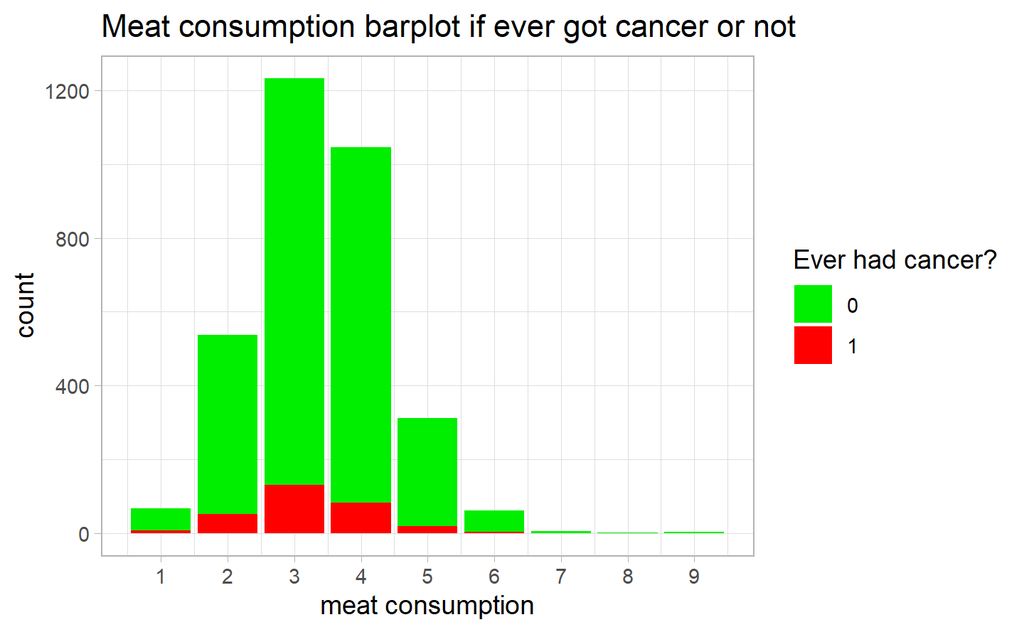

We can see that the greater the frequency is, the greater the gap in barplot is.

We display a table and a barplot to count the number of cancer and the proportion by frequency of meat consumption.

**Cancer by meat consumption categories**

| meat_cons | got_cancer | count | proportion |
| --- | --- | --- | --- |
| Never | 0 | 59 | 0.881 |
| Never | 1 | 8 | 0.119 |
| Low | 0 | 1592 | 0.897 |
| Low | 1 | 182 | 0.103 |
| Moderate | 0 | 1315 | 0.926 |
| Moderate | 1 | 105 | 0.074 |
| High | 0 | 12 | 1.000 |

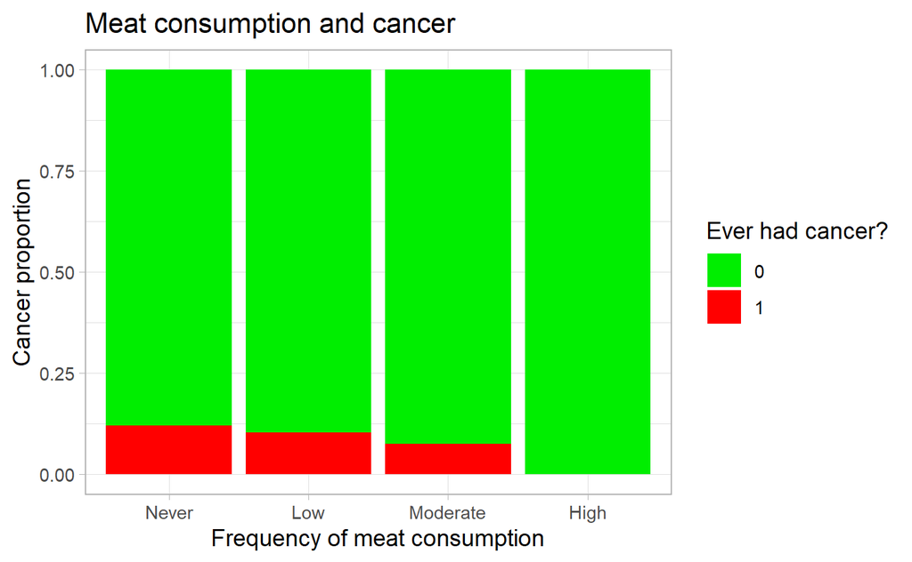

It can be seen that, surprisingly, respondents who never eat meat, which can therefore be considered vegetarians are the category which got more cancer in proportion, we can observe a trend but we must take into account that the high category have no cancer also because this category is small.

We create a GLM regression with meat explaining cancer and we compute the pseudo Rsquared.

```
#>
#> Call:
#> glm(formula = got_cancer ~ meat_cons, family = binomial(link = "logit"),
#>     data = join_food_other_cancer)
#>
#> Deviance Residuals:
#>    Min      1Q  Median      3Q     Max
#> -0.527  -0.446  -0.446  -0.410   2.386
#>
#> Coefficients:
#>             Estimate Std. Error z value            Pr(>|z|)
#> (Intercept)  -1.7266     0.2069   -8.34 <0.0000000000000002 ***
#> meat_cons    -0.1766     0.0612   -2.89              0.0039 **
#> ---
#> Signif. codes:  0 '***' 0.001 '**' 0.01 '*' 0.05 '.' 0.1 ' ' 1
#>
#> (Dispersion parameter for binomial family taken to be 1)
#>
#>     Null deviance: 1981.3  on 3266  degrees of freedom
#> Residual deviance: 1972.8  on 3265  degrees of freedom
#>   (3 observations deleted due to missingness)
#> AIC: 1977
#>
#> Number of Fisher Scoring iterations: 5
#> fitting null model for pseudo-r2
#>        llh    llhNull         G2   McFadden       r2ML       r2CU
#> -986.38955 -990.63354    8.48797    0.00428    0.00259    0.00571
```

It is seen that the meat consumption coefficient has a negative effect on cancer and a significant p-value at a level of 5%. However, McFadden’s pseudo R^2 is 0.43%, which means that meat explains 0.43% of the variation in cancer. This variable will be included in the partial model because it is significant.

Here is an illustration of the GLM regression:.

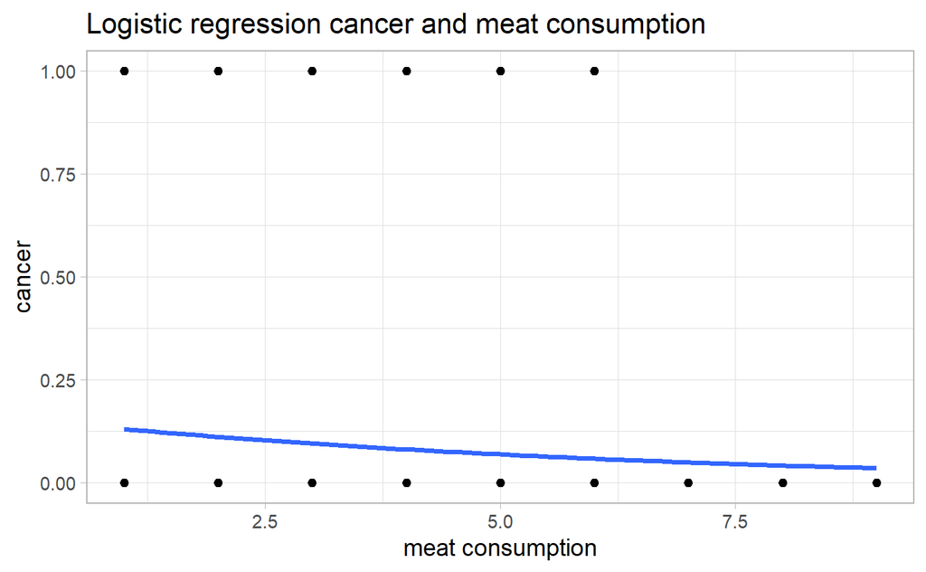

### 4.3.2 Cancer and dairy products

We create a table including our got_cancer and our dairy products variables.

**Cancer and dairy products consumption variables**

| SEQN | dairy_cons | got_cancer |
| --- | --- | --- |
| 31131 | moderate | 0 |
| 31132 | low | 0 |
| 31134 | moderate | 0 |
| 31144 | high | 0 |
| 31150 | moderate | 1 |
| 31151 | low | 0 |

Here is an illustration of the dairy products consumption barplot depending whether the respondens ever had cancer or not.

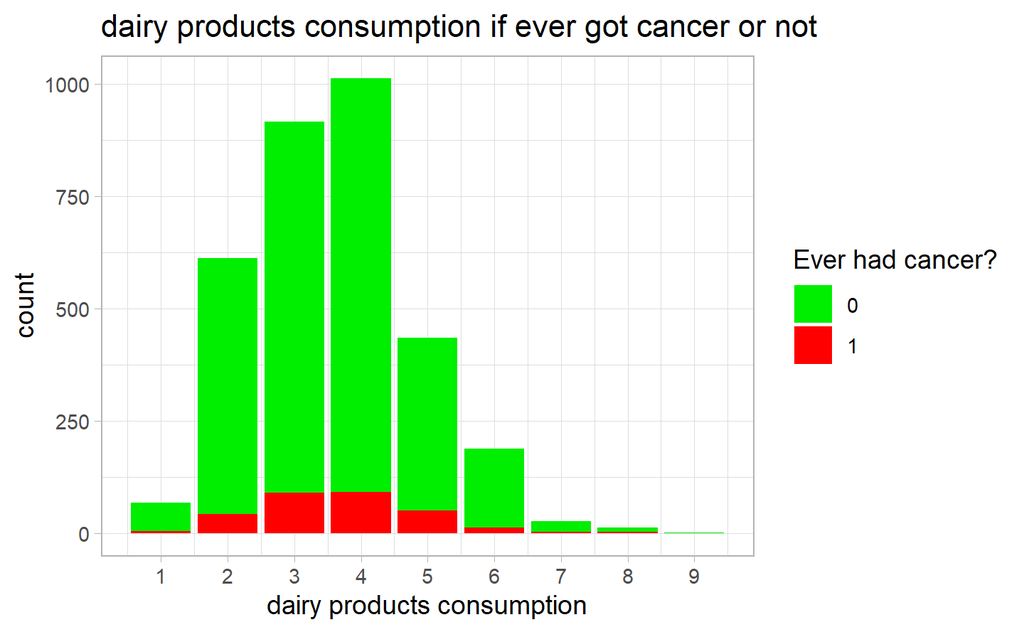

We can see that the greater the frequency is, the smaller the gap in barplot is between the two groups.

We display a table and a barplot to count the number of cancers and the proportion by frequency of consumption of dairy products.

**Cancer by frequency of consumption of dairy products**

| dairy_cons | got_cancer | count | proportion |
| --- | --- | --- | --- |
| never | 0 | 66 | 0.943 |
| never | 1 | 4 | 0.057 |
| low | 0 | 1400 | 0.914 |
| low | 1 | 132 | 0.086 |
| moderate | 0 | 1481 | 0.906 |
| moderate | 1 | 153 | 0.094 |
| high | 0 | 33 | 0.846 |
| high | 1 | 6 | 0.154 |

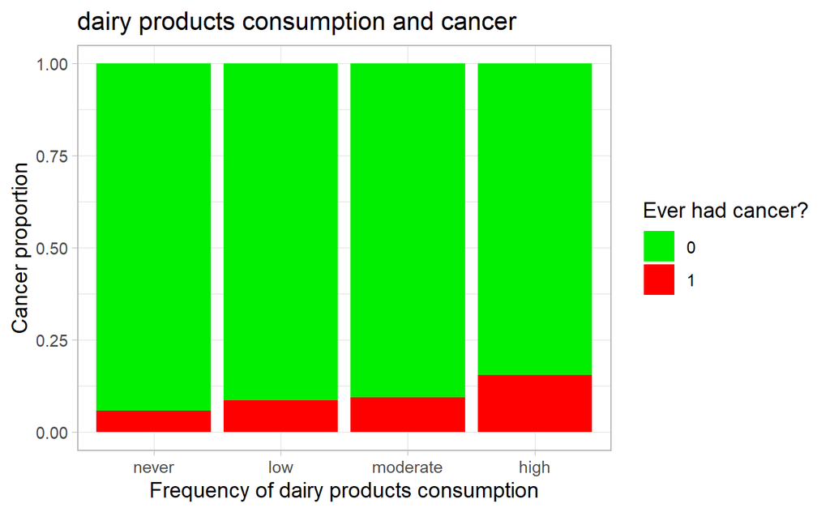

It can be seen here that the more the frequency of consumption of dairy products increases, the more respondents actually had cancer.

We create a GLM regression with dairy products consumption explaining cancer and we compute the pseudo Rsquared

```
#>
#> Call:
#> glm(formula = got_cancer ~ dairy_cons, family = binomial(link = "logit"),
#>     data = join_food_other_cancer)
#>
#> Deviance Residuals:
#>    Min      1Q  Median      3Q     Max
#> -0.540  -0.442  -0.424  -0.407   2.285
#>
#> Coefficients:
#>             Estimate Std. Error z value            Pr(>|z|)
#> (Intercept)  -2.6195     0.1887  -13.88 <0.0000000000000002 ***
#> dairy_cons    0.0854     0.0485    1.76               0.079 .
#> ---
#> Signif. codes:  0 '***' 0.001 '**' 0.01 '*' 0.05 '.' 0.1 ' ' 1
#>
#> (Dispersion parameter for binomial family taken to be 1)
#>
#>     Null deviance: 1981.3  on 3266  degrees of freedom
#> Residual deviance: 1978.2  on 3265  degrees of freedom
#>   (3 observations deleted due to missingness)
#> AIC: 1982
#>
#> Number of Fisher Scoring iterations: 5
#> fitting null model for pseudo-r2
#>         llh     llhNull          G2    McFadden        r2ML
#> -989.101825 -990.633537    3.063426    0.001546    0.000937
#>        r2CU
#>    0.002061
```

We can see that the dairy products consumption coefficient has a positive effect on cancer and a significant p-value at 10%, so it will not be included in the partial model. McFadden’s pseudo R^2 is 0.16%, which means that dairy products explains 0.16% of the variation in cancer.

Here is an illustration of the GLM regression:

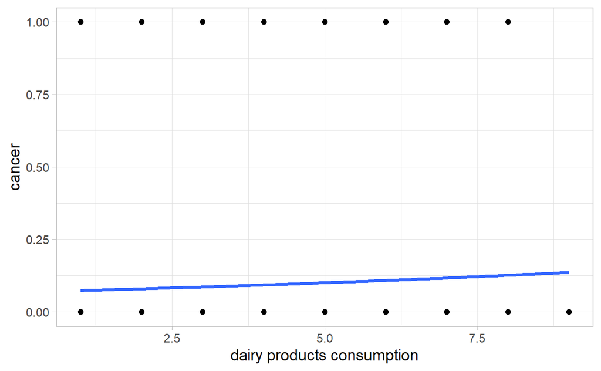

### 4.3.3 Cancer and Vegetables

We create a table including our got_cancer and our vegetables variables.

**Cancer and vegetables consumption variables**

| SEQN | vege_cons | got_cancer |
| --- | --- | --- |
| 31131 | moderate | 0 |
| 31132 | low | 0 |
| 31134 | low | 0 |
| 31144 | moderate | 0 |
| 31150 | moderate | 1 |
| 31151 | low | 0 |

Here is an illustration of the vegetable consumption barplot depending whether respondents ever had cancer or not.

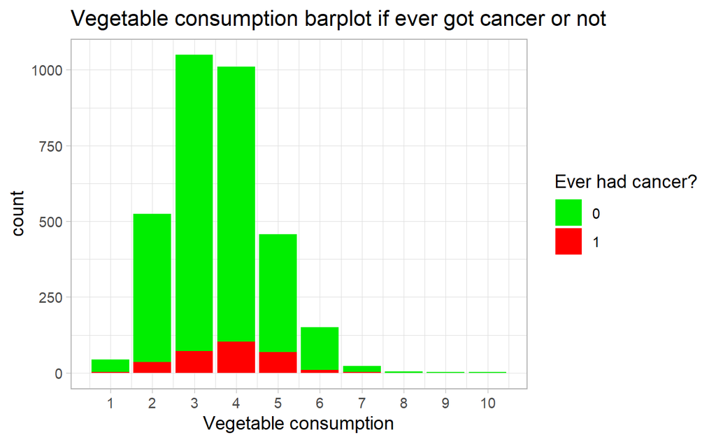

We display a table and a barplot to count the number of cancers and the proportion by frequency of consumption of vegetables.

**Cancer by frequency of consumption of vegetables**

| vege_cons | got_cancer | count | proportion |
| --- | --- | --- | --- |
| never | 0 | 40 | 0.930 |
| never | 1 | 3 | 0.070 |
| low | 0 | 1470 | 0.932 |
| low | 1 | 108 | 0.068 |
| moderate | 0 | 1438 | 0.888 |
| moderate | 1 | 181 | 0.112 |
| high | 0 | 28 | 0.903 |
| high | 1 | 3 | 0.097 |

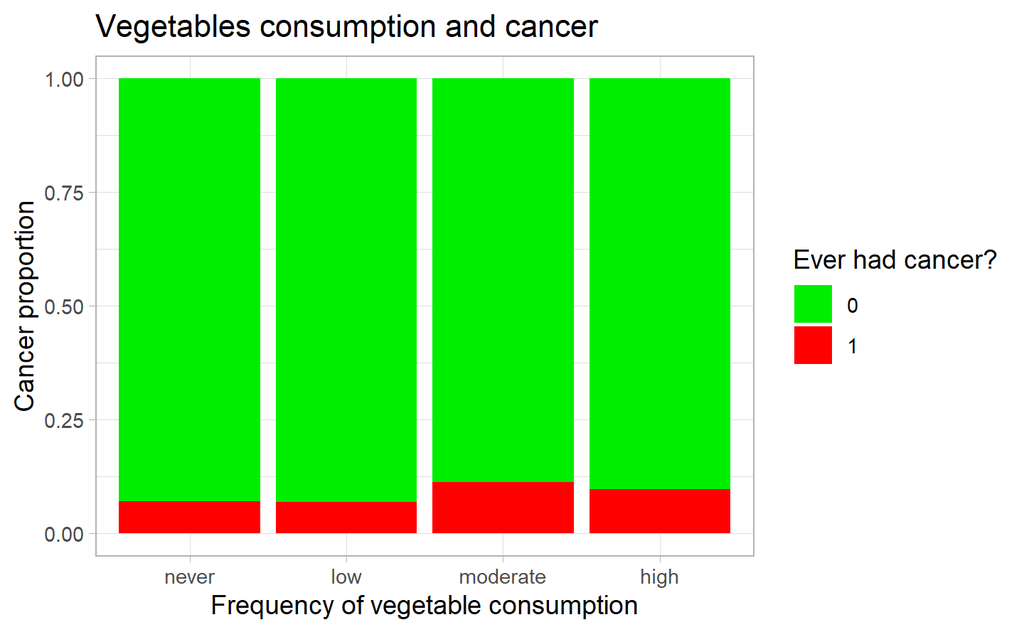

We do not necessarily see a difference or relationship, depending on the frequency of vegetable consumption and the fact of having had cancer.

We create a GLM regression with vegetable consumption explaining cancer and we compute the pseudo Rsquared

```
#>
#> Call:
#> glm(formula = got_cancer ~ vege_cons, family = binomial(link = "logit"),
#>     data = join_food_other_cancer)
#>
#> Deviance Residuals:
#>    Min      1Q  Median      3Q     Max
#> -0.731  -0.447  -0.410  -0.377   2.386
#>
#> Coefficients:
#>             Estimate Std. Error z value             Pr(>|z|)
#> (Intercept)  -2.9660     0.2009  -14.76 < 0.0000000000000002 ***
#> vege_cons     0.1781     0.0506    3.52              0.00043 ***
#> ---
#> Signif. codes:  0 '***' 0.001 '**' 0.01 '*' 0.05 '.' 0.1 ' ' 1
#>
#> (Dispersion parameter for binomial family taken to be 1)
#>
#>     Null deviance: 1981.3  on 3266  degrees of freedom
#> Residual deviance: 1969.1  on 3265  degrees of freedom
#>   (3 observations deleted due to missingness)
#> AIC: 1973
#>
#> Number of Fisher Scoring iterations: 5
#> fitting null model for pseudo-r2
#>        llh    llhNull         G2   McFadden       r2ML       r2CU
#> -984.56768 -990.63354   12.13172    0.00612    0.00371    0.00815
```

It is seen that the coefficient of vegetable consumption has a positive effect on cancer and a significant p-value at a level of 0.1%, this variable will be included in the partial model. McFadden’s pseudo R ^ 2 is 0.62%, which means that vegetable consumption explains 0.62% of the variation in cancer.

Here is an illustration of the GLM regression:

[figure not shown]

### 4.3.4 Cancer and Fruits

We create a table including our got_cancer and our fruits variables.

**Cancer and fruits consumption variables**

| SEQN | fruit_cons | got_cancer |
| --- | --- | --- |
| 31131 | moderate | 0 |
| 31132 | low | 0 |
| 31134 | low | 0 |
| 31144 | moderate | 0 |
| 31150 | moderate | 1 |
| 31151 | low | 0 |

Here is an illustration of the fruit consumption barplot depending whether respondents ever had cancer or not.

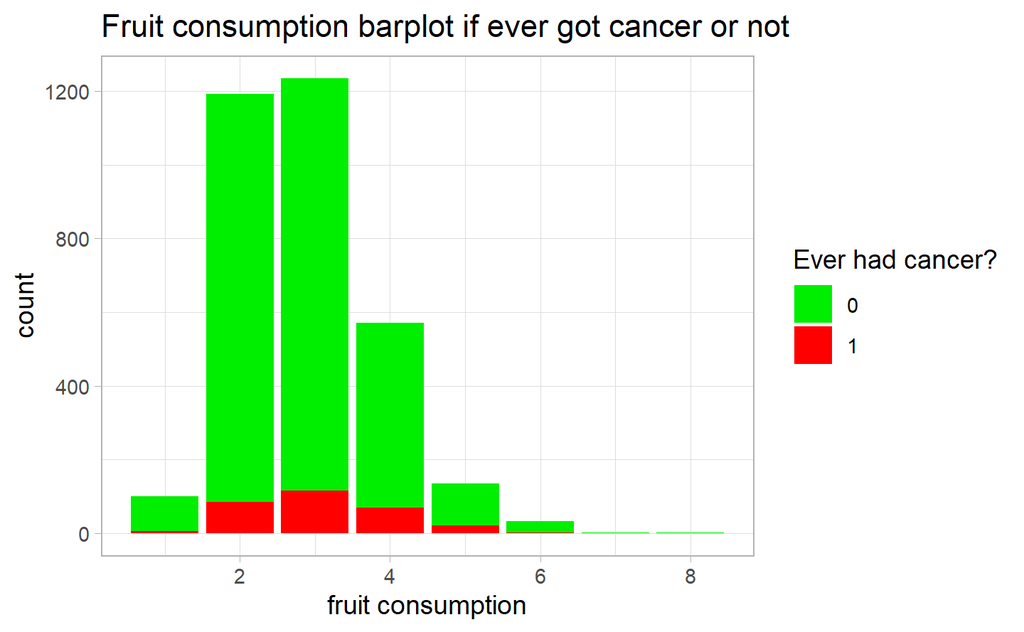

We can see that the greater the frequency is, the smaller the gap in barplot is between the two groups.

We display a table and a barplot to count the number of cancers and the proportion by frequency of consumption of fruits.

**Cancer by frequency of consumption of fruits**

| fruit_cons | got_cancer | count | proportion |
| --- | --- | --- | --- |
| never | 0 | 96 | 0.950 |
| never | 1 | 5 | 0.050 |
| low | 0 | 2235 | 0.918 |
| low | 1 | 200 | 0.082 |
| moderate | 0 | 647 | 0.878 |
| moderate | 1 | 90 | 0.122 |
| high | 0 | 3 | 1.000 |

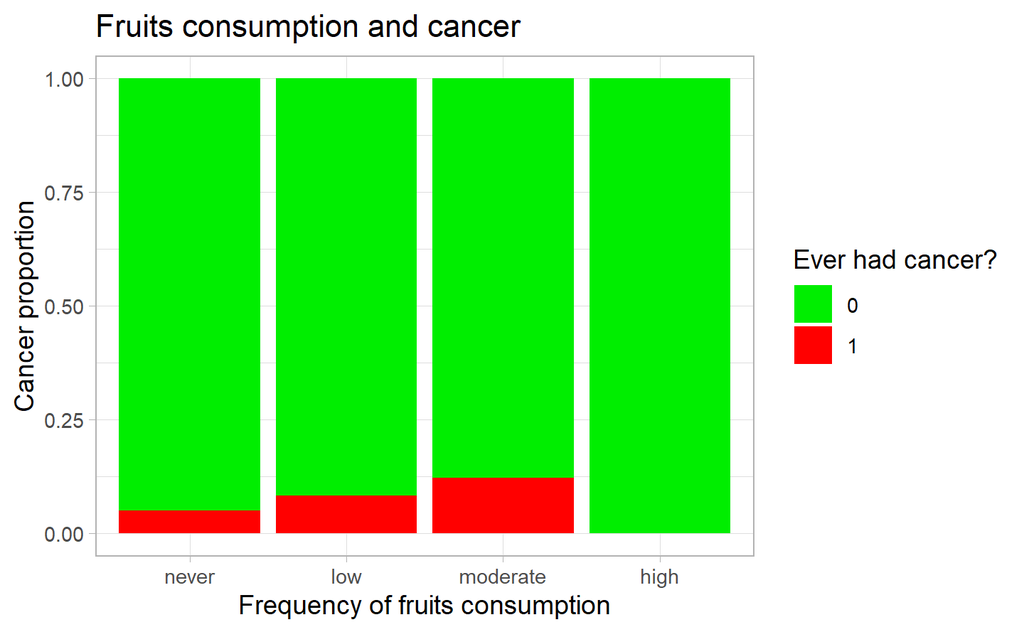

We can clearly see that the higher the frequency of fruit consumption among our respondents, the more they have cancer. Respondents with high consumption have no cancer probably because this category is very small.

We create a GLM regression with fruit consumption explaining cancer and we compute the pseudo Rsquared

```
#>
#> Call:
#> glm(formula = got_cancer ~ fruit_cons, family = binomial(link = "logit"),
#>     data = join_food_other_cancer)
#>
#> Deviance Residuals:
#>    Min      1Q  Median      3Q     Max
#> -0.739  -0.437  -0.437  -0.392   2.374
#>
#> Coefficients:
#>             Estimate Std. Error z value             Pr(>|z|)
#> (Intercept)  -2.9835     0.1938  -15.39 < 0.0000000000000002 ***
#> fruit_cons    0.2282     0.0605    3.77              0.00016 ***
#> ---
#> Signif. codes:  0 '***' 0.001 '**' 0.01 '*' 0.05 '.' 0.1 ' ' 1
#>
#> (Dispersion parameter for binomial family taken to be 1)
#>
#>     Null deviance: 1981.3  on 3266  degrees of freedom
#> Residual deviance: 1967.5  on 3265  degrees of freedom
#>   (3 observations deleted due to missingness)
#> AIC: 1971
#>
#> Number of Fisher Scoring iterations: 5
#> fitting null model for pseudo-r2
#>        llh    llhNull         G2   McFadden       r2ML       r2CU
#> -983.74643 -990.63354   13.77422    0.00695    0.00421    0.00925
```

It can be seen that the fruit consumption coefficient has a positive effect on cancer and a significant p-value at 0.1%, this variable will be included in the partial model. McFadden’s pseudo R^2 is 0.7%, which means that fruits explains 0.7% of the variation in cancer.

Here is an illustration of the GLM regression:

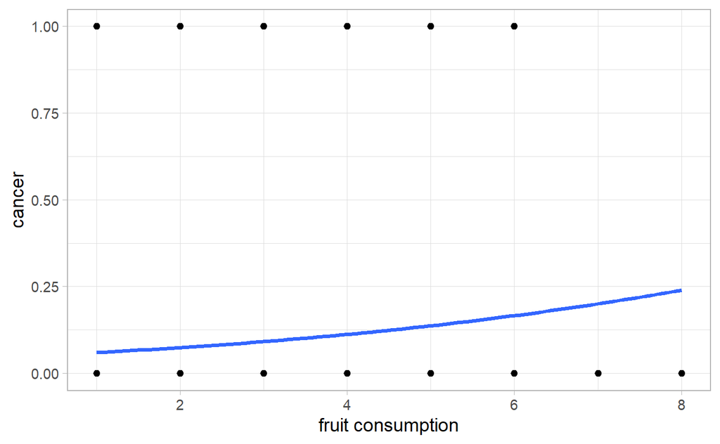

### 4.3.5 Cancer and diet type.

We create a table including our `got_cancer` and the type of `diet` variables.

**Cancer and the type of diet followed variables**

| SEQN | diet | got_cancer |
| --- | --- | --- |
| 31130 | Good | 0 |
| 31131 | Good | 0 |
| 31132 | Very_good | 0 |
| 31134 | Good | 0 |
| 31136 | Good | 0 |
| 31144 | Excellent | 0 |

Here is an illustration of the diet barplot depending whether respondents ever had cancer or not.

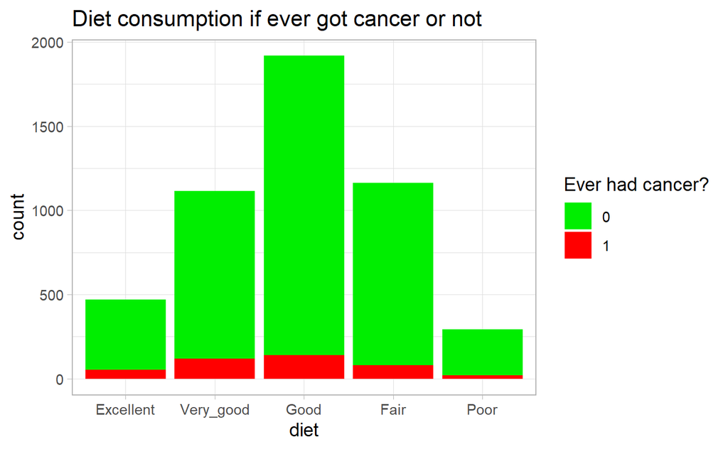

We display a table and a barplot to count the number of cancers and the proportion by the type of diet followed.

**Cancer by the type of diet followed**

| diet | got_cancer | count | proportion |
| --- | --- | --- | --- |
| Excellent | 0 | 417 | 0.885 |
| Excellent | 1 | 54 | 0.115 |
| Very_good | 0 | 997 | 0.893 |
| Very_good | 1 | 119 | 0.107 |
| Good | 0 | 1779 | 0.927 |
| Good | 1 | 140 | 0.073 |
| Fair | 0 | 1084 | 0.931 |
| Fair | 1 | 80 | 0.069 |
| Poor | 0 | 274 | 0.932 |
| Poor | 1 | 20 | 0.068 |

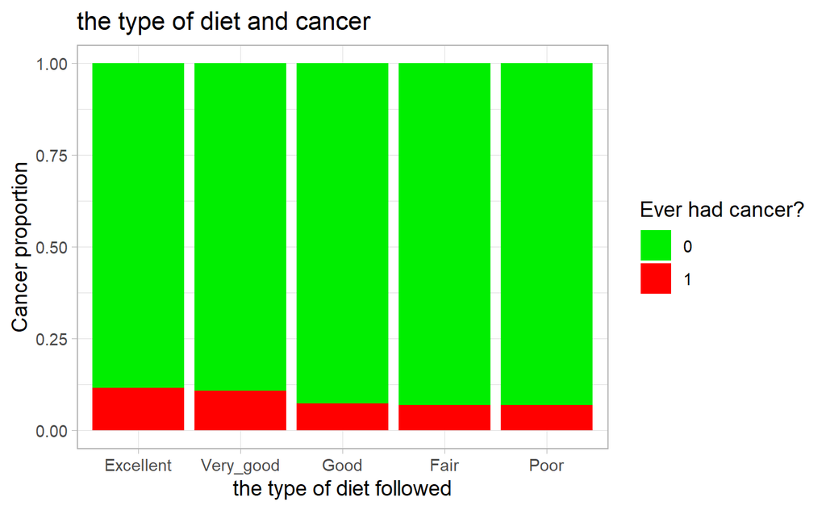

We create a GLM regression with diet explaining cancer and we compute the pseudo Rsquared.

```
#>
#> Call:
#> glm(formula = got_cancer ~ diet, family = binomial(link = "logit"),
#>     data = join_food_other_cancer)
#>
#> Deviance Residuals:
#>    Min      1Q  Median      3Q     Max
#> -0.528  -0.473  -0.424  -0.380   2.401
#>
#> Coefficients:
#>             Estimate Std. Error z value             Pr(>|z|)
#> (Intercept)  -1.6692     0.1717   -9.72 < 0.0000000000000002 ***
#> diet         -0.2312     0.0602   -3.84              0.00012 ***
#> ---
#> Signif. codes:  0 '***' 0.001 '**' 0.01 '*' 0.05 '.' 0.1 ' ' 1
#>
#> (Dispersion parameter for binomial family taken to be 1)
#>
#>     Null deviance: 1980.3  on 3261  degrees of freedom
#> Residual deviance: 1965.4  on 3260  degrees of freedom
#>   (8 observations deleted due to missingness)
#> AIC: 1969
#>
#> Number of Fisher Scoring iterations: 5
#> fitting null model for pseudo-r2
#>        llh    llhNull         G2   McFadden       r2ML       r2CU
#> -982.70808 -990.15997   14.90377    0.00753    0.00456    0.01002
```

We can see that the weight of the diet has a negative effect on cancer. Here, we have to be careful because a healthy diet = 1 and a bad diet = 5. This therefore means that a healthier diet has a positive relationship with cancer and as the p-value is significant at 0.1%, this variable will be included in the partial model. McFadden’s pseudo R ^ 2 is 0.75%, which means that the diet type explains 0.75% of the variation in cancer.

Here is an illustration of the GLM regression:

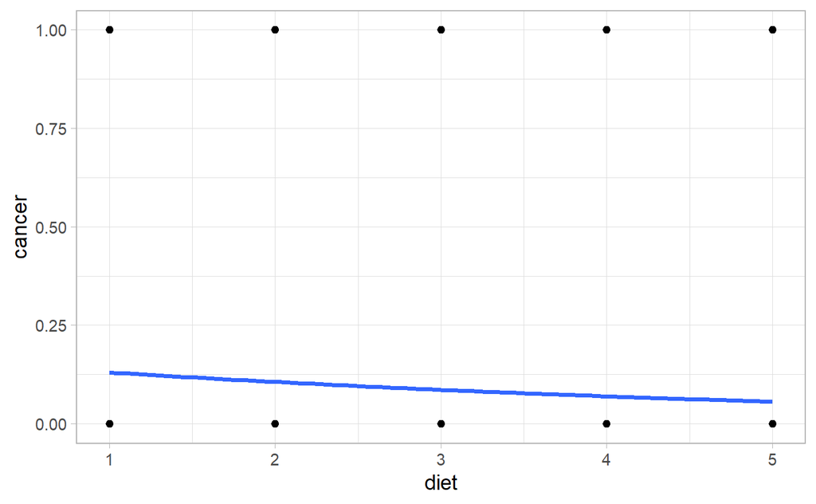

## 4.4 Multivariate cancer modelling

Now we will start by calculating the partial model with all the individually significant variables, then we will create a model with all the variables (significant and non-significant) and finally we will compare these two models.

### 4.4.1 Multivariate partial model

We create a partial model with all the significant variables at the 5% level, which we saw previously:

- Age
- Alcohol
- Smoking
- Meat consumption
- Vegetable consumption
- Fruit consumption
- Type of diet

Here is the GLM regression explaining cancer and with pseudo Rsquared

```
#>
#> Call:
#> glm(formula = got_cancer ~ age + avg_alcohol + cigarets_per_day +
#>     meat_cons + vege_cons + fruit_cons + diet, family = binomial(link = "logit"),
#>     data = join_food_other_cancer)
#>
#> Deviance Residuals:
#>    Min      1Q  Median      3Q     Max
#> -0.767  -0.349  -0.286  -0.221   2.634
#>
#> Coefficients:
#>                  Estimate Std. Error z value Pr(>|z|)
#> (Intercept)      -4.59715    1.68482   -2.73   0.0064 **
#> age               0.02363    0.01609    1.47   0.1420
#> avg_alcohol      -0.02913    0.09846   -0.30   0.7674
#> cigarets_per_day  0.00472    0.02289    0.21   0.8366
#> meat_cons        -0.36447    0.25843   -1.41   0.1585
#> vege_cons         0.29062    0.25981    1.12   0.2633
#> fruit_cons        0.13678    0.32000    0.43   0.6691
#> diet              0.14981    0.24160    0.62   0.5352
#> ---
#> Signif. codes:  0 '***' 0.001 '**' 0.01 '*' 0.05 '.' 0.1 ' ' 1
#>
#> (Dispersion parameter for binomial family taken to be 1)
#>
#>     Null deviance: 158.30  on 394  degrees of freedom
#> Residual deviance: 150.18  on 387  degrees of freedom
#>   (2875 observations deleted due to missingness)
#> AIC: 166.2
#>
#> Number of Fisher Scoring iterations: 6
#> fitting null model for pseudo-r2
#>      llh  llhNull       G2 McFadden     r2ML     r2CU
#> -75.0890 -79.1480   8.1178   0.0513   0.0203   0.0616
```

We notice that our partial model including only our individually significant variables, gives us as results that none of our variables is now significant, only the intercept is significant. We can also notice that the pseudo McFadden rsquared has a value of 0.0513 and therefore that only 5.13% of the variation in cancer is explained by this model. Therefore, this model is extremely poor at predicting cancer as a good model should ideally have a McFadden rsquared value greater than 70% or even 80%.

### 4.4.2 Multivariate full model

We build a complete model including all the variables we explored previously, including those that were not significant at first, and then using the AIC method for variable selection.

```
#>
#> Call:
#> glm(formula = got_cancer ~ age + gender + income + avg_physical_activity +
#>     avg_alcohol + cigarets_per_day + meat_cons + dairy_cons +
#>     vege_cons + fruit_cons + diet, family = binomial(link = "logit"),
#>     data = join_food_other_cancer %>% drop_na())
#>
#> Deviance Residuals:
#>    Min      1Q  Median      3Q     Max
#> -0.797  -0.337  -0.224  -0.161   2.915
#>
#> Coefficients:
#>                       Estimate Std. Error z value Pr(>|z|)
#> (Intercept)           -8.16906    2.56406   -3.19   0.0014 **
#> age                    0.02535    0.01880    1.35   0.1775
#> gender                 1.40936    0.63000    2.24   0.0253 *
#> income                -0.02046    0.09039   -0.23   0.8209
#> avg_physical_activity  0.12066    0.29711    0.41   0.6847
#> avg_alcohol            0.04693    0.10699    0.44   0.6609
#> cigarets_per_day       0.00751    0.02574    0.29   0.7705
#> meat_cons             -0.42881    0.29311   -1.46   0.1435
#> dairy_cons             0.41119    0.24489    1.68   0.0931 .
#> vege_cons              0.19348    0.30446    0.64   0.5251
#> fruit_cons            -0.09215    0.37662   -0.24   0.8067
#> diet                   0.27474    0.26588    1.03   0.3015
#> ---
#> Signif. codes:  0 '***' 0.001 '**' 0.01 '*' 0.05 '.' 0.1 ' ' 1
#>
#> (Dispersion parameter for binomial family taken to be 1)
#>
#>     Null deviance: 145.50  on 385  degrees of freedom
#> Residual deviance: 129.01  on 374  degrees of freedom
#> AIC: 153
#>
#> Number of Fisher Scoring iterations: 6
#> fitting null model for pseudo-r2
#>      llh  llhNull       G2 McFadden     r2ML     r2CU
#> -64.5073 -72.7520  16.4894   0.1133   0.0418   0.1332
```

```
#> Start:  AIC=153
#> got_cancer ~ age + gender + income + avg_physical_activity +
#>     avg_alcohol + cigarets_per_day + meat_cons + dairy_cons +
#>     vege_cons + fruit_cons + diet
#>
#>                         Df Deviance AIC
#> - income                 1      129 151
#> - fruit_cons             1      129 151
#> - cigarets_per_day       1      129 151
#> - avg_physical_activity  1      129 151
#> - avg_alcohol            1      129 151
#> - vege_cons              1      129 151
#> - diet                   1      130 152
#> - age                    1      131 153
#> <none>                          129 153
#> - meat_cons              1      131 153
#> - dairy_cons             1      132 154
#> - gender                 1      135 157
#>
#> Step:  AIC=151
#> got_cancer ~ age + gender + avg_physical_activity + avg_alcohol +
#>     cigarets_per_day + meat_cons + dairy_cons + vege_cons + fruit_cons +
#>     diet
#>
#>                         Df Deviance AIC
#> - fruit_cons             1      129 149
#> - cigarets_per_day       1      129 149
#> - avg_physical_activity  1      129 149
#> - avg_alcohol            1      129 149
#> - vege_cons              1      129 149
#> - diet                   1      130 150
#> <none>                          129 151
#> - age                    1      131 151
#> - meat_cons              1      131 151
#> - dairy_cons             1      132 152
#> - gender                 1      135 155
#>
#> Step:  AIC=149
#> got_cancer ~ age + gender + avg_physical_activity + avg_alcohol +
#>     cigarets_per_day + meat_cons + dairy_cons + vege_cons + diet
```

[output cut: 110 more lines]

```
#> (Intercept)   -5.561      1.047   -5.31 0.00000011 ***
#> gender         1.582      0.577    2.74     0.0061 **
#> ---
#> Signif. codes:  0 '***' 0.001 '**' 0.01 '*' 0.05 '.' 0.1 ' ' 1
#>
#> (Dispersion parameter for binomial family taken to be 1)
#>
#>     Null deviance: 145.50  on 385  degrees of freedom
#> Residual deviance: 136.29  on 384  degrees of freedom
#> AIC: 140.3
#>
#> Number of Fisher Scoring iterations: 6
#> fitting null model for pseudo-r2
#>      llh  llhNull       G2 McFadden     r2ML     r2CU
#> -68.1443 -72.7520   9.2154   0.0633   0.0236   0.0751
```

### 4.4.3 Model comparison and interpretration

The full model is therefore better than the partial model with a McFadden pseudo-square of 11.33% compared to 5.13%. Even though it is preferable, 11.33% is still a very poor value for predicting cancer. There must be either an important variable explaining a part of the cancer than the one we have studied or else the cancer has a large number of variables with each of them having a small effect, which is the most probable as we included some variables known to cause some cancers.

In the end, there are two significant variables which we can be identified: - Gender at the 5% level - Consumption of dairy products at the 10% level (which could be considered too high)

However, one thing that is interesting to observe is the direction of the coefficient of each variable, with a model including all variables:

-`age` 0.025 is positive, as we would expect the greater the age is the greater the odds that you got cancer are.  
-`gender` 1.409 is positive meaning the odds to get a cancer are greater for women.  
-`income` -0.02 is negative meaning the odds to get a cancer are smaller the more income you get.  
-`avg_physical_activity` 0.121 is positive, which is the opposite of what we would expect meaning more physical activity the greater the odds to have a cancer are.  
-`avg_alcohol` 0.047 is positive which we would expect before starting this project, but which contradict what we observe in point 4.2.5, where it appeared surprisingly more as a negative relationship with cancer.  
-`cigarettes_per_day` 0.008 is positive as we could expect.

-`meat_cons` -0.429 is negative meaning the odds to get cancer are smaller the more you eat meat, which contradict our hypothesis.  
-`dairy_cons` 0.411 is positive meaning the odds to get cancer are greater the more you eat dairy products, which goes in the same direction than our hypothesis.  
-`vege_cons` 0.193 is positive meaning the odds to get cancer are greater the more vegetables you eat, which contradict our hypothesis.  
-`fruit_cons` -0.092 is negative, which goes in the same direction than our hypothesis, but contradict what we observed in point 4.3.4. Moreover we have to keep in mind that this variable is correlated (50%) with vegetable.  
-`diet` 0.275 is positive in that case (for this variable value are ranked for 1 for healthy to 5 for poor) it means the less healthy you eat the greater the odds to get cancer are, which goes in the same direction than our hypothesis, but contradict what we observed in point 4.3.5.

## 4.5 Answering research questions

Finally, our variables are not good enough to predict cancer, because the best model we could make could only explain 11.33% of the variation in cancer, so the influence of our variables individually is extremely small and questionable as we have seen.  
Our hypotheses were that eating healthy, meaning eating vegetables and fruits and therefore having a good diet would reduce the risk of cancer and that, on the contrary, animal products (meat and dairy products) would increase the risk of cancer.  
However, these assumptions are not supported by our model, when it includes confounding variables, except for the dairy product which has an effect but weak and is the only food variable which is significant, and only at a level of 10%.

# **5 Conclusion**

At the first sight when we investigated the relationship between food and cancer it looked like there were relationships, but it was no longer the case once we introduced potential confounding variables. In the end, only gender and potentially dairy product consumption have an effect. So, it was a good application of this principle for us, as at the very beginning of our project we were not thinking about that which would have lead us to very biased and unrealistic results.

Although we included many variables that are known to have a relationship with certain cancer, such as smoking, drinking, it is very far from enough to predict cancer, as our model showed us. All the variables in our study have only a very small or no effect, it is therefore very difficult to determine a particular cause. There could also be for sure much more variables that were not in the scope of this study (such as genetic or stress level, and more) that could influence cancer or influence the significance of other variables. Moreover, there was only cancer data about adults which might lower the age’s overall effect on our results. Therefore remaining cautious, we cannot come out of this study with precisely identifying a clear relationship or effect between eating habits and cancer. But aside of that our data suggest that gender has an effect on cancer, meaning women got significantly more cancers than men in our sample of respondents.

For the future, investigating every particular cancer types compared to particular eating habits could be a potential interesting work. But to do that we would need other data sets with a wider pool of observations for each type of cancer, as our dataset had a very limited number of observations by type of cancer.